# HDT2 Clustering

Cristopher Barrios, Carlos Daniel Estrada

16/2/2023

```r
library(dplyr)
```

```r
library(ggplot2)

# Utilizados en el laboratorio
library(hopkins)
library(ggplot2)
library(factoextra)
library(fpc)
library(cluster)

datos <- read.csv("movies.csv")
```

### 1. Haga el preprocesamiento del dataset, explique qué variables no aportan información a la generación de grupos y por qué. Describa con qué variables calculará los grupos.

- Variables que no aportan:
- Id: Solo es una variable para identificar cada pelicula
- title: al estar usando el titulo original, no es necesaria esta variable
- homePage: es una variable cualtitiva
- video: es una variables booleana
- director: no es una variable numérica
- productionCompany: no es una variable numérica
- productionCountry:no es una variable numérica
- actors: no es una variable numérica
- actorsCharacter:no es una variable numérica
- Variables que si aportan:

### 2. Analice la tendencia al agrupamiento usando el estadístico de Hopkings y la VAT (Visual Assessment of cluster Tendency). Discuta sus resultados e impresiones.

```r
#numericas <- datos[,c("popularity","budget","revenue","runtime","genreAmount","productionCoAmount")]
#hopkins()
datos<-datos[complete.cases(read.csv("movies.csv")),]

popularity<-datos[,'popularity']
budget<-datos[,'budget']
revenue<-datos[,'revenue']
runtime<-datos[,'runtime']
voteCount<-datos[,'voteCount']

norm<-data.frame(popularity,budget,revenue,runtime,voteCount)
clustering<-scale(norm)
hopkins(clustering)
```

```
## [1] 0.9999949
```

En esto caso el resultado que se obtuvo de la funcion de hopkins esta lejos del o.5 este nos da 0.9 por lo que se puede determinar que los datos que se nos proveen no son aleatorios, entonces el agrupamiento posterior de este sera mas sencillo

```r
DistData<- dist(clustering)
```

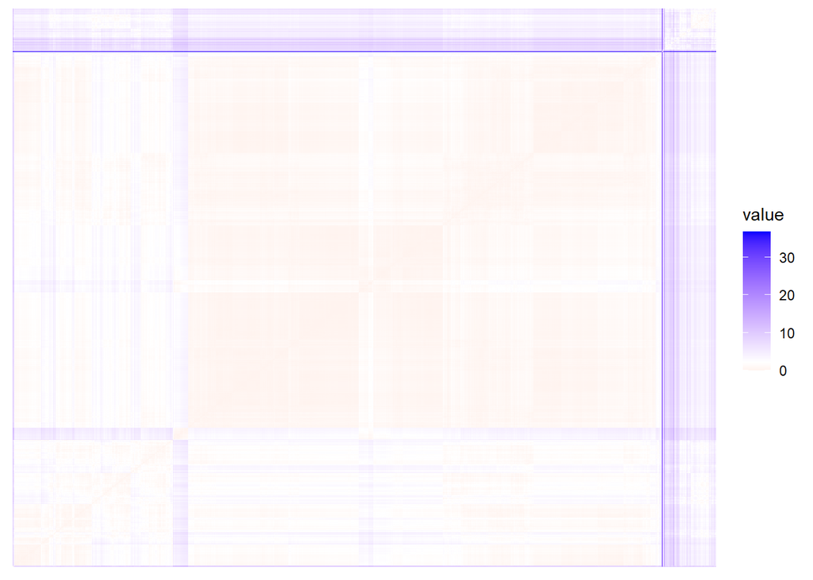

```r
knitr::opts_chunk$set(fig.width=12, fig.height=8)
fviz_dist(DistData, show_labels = F)
```

### 3. Determine cuál es el número de grupos a formar más adecuado para los datos que está trabajando.

Haga una gráfica de codo y explique la razón de la elección de la cantidad de clústeres con la que trabajará.

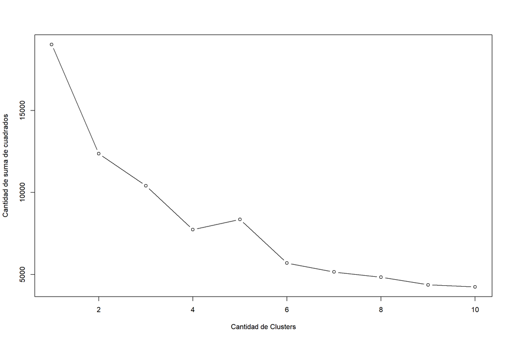

```r
wss <- (nrow(clustering)-1)*sum(apply(clustering,2,var))
for (i in 1:10)
  wss[i] <- sum(kmeans(clustering, centers=i)$withinss)
plot(1:10, wss, type="b", xlab="Cantidad de Clusters",  ylab="Cantidad de suma de cuadrados")
```

Como podemos observar en la grafica de codo el numero de clusters que mejor se acomoda es el de 6

```r
NClusters <- 6
```

### 4. Utilice los algoritmos k-medias y clustering jerárquico para agrupar. Compare los resultados generados por cada uno.

K-means

### 5. Determine la calidad del agrupamiento hecho por cada algoritmo con el método de la silueta. Discuta los resultados.

K-means

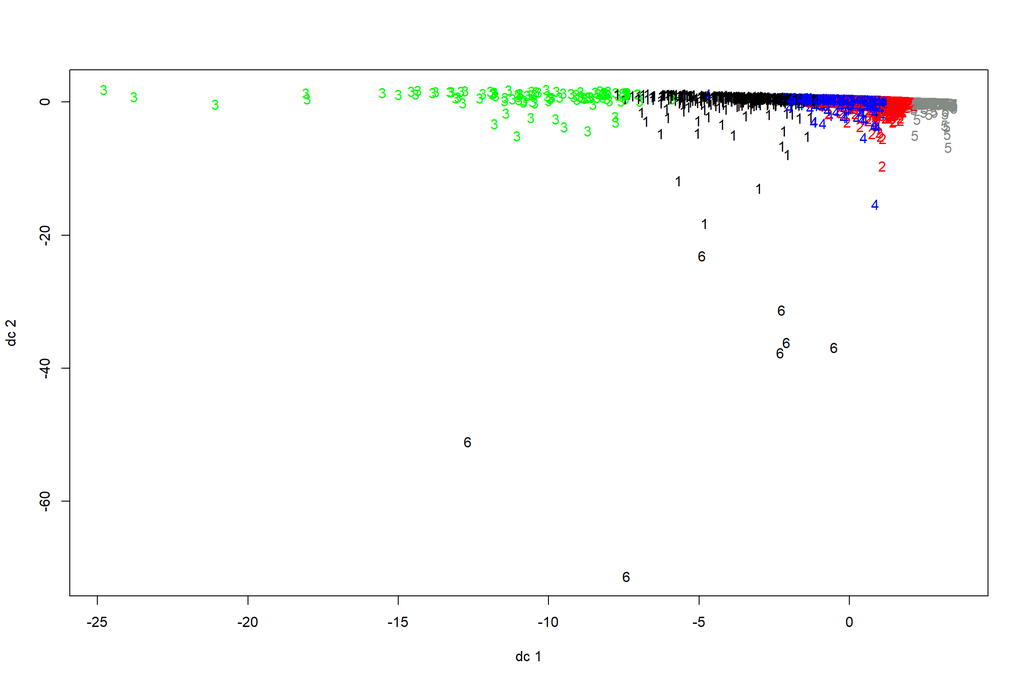

```r
km<-kmeans(clustering,NClusters,iter.max =100)
datos$grupo<-km$cluster
plotcluster(clustering,km$cluster)
```

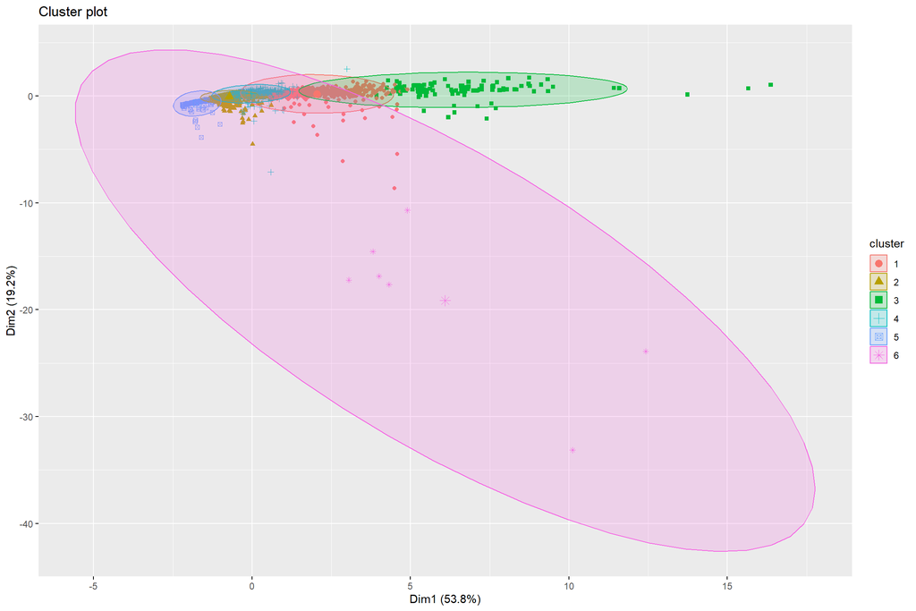

```r
#silueta
fviz_cluster(km, data = clustering,geom = "point", ellipse.type = "norm")
```

```r
SiluetaK<-silhouette(km$cluster,dist(clustering))
mean(SiluetaK[,3])
```

```
## [1] 0.3443553
```

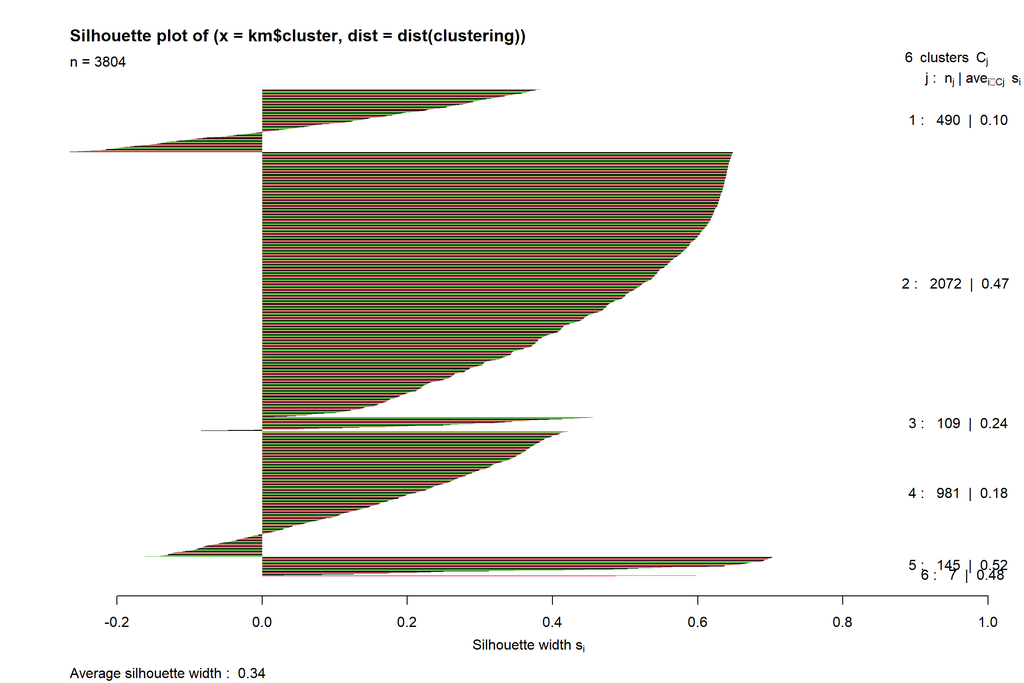

```r
Kmean<-mean(SiluetaK[,3])
plot(SiluetaK, cex.names=.4, col=1:3, border=NA)
```

Cluster Jerarquico

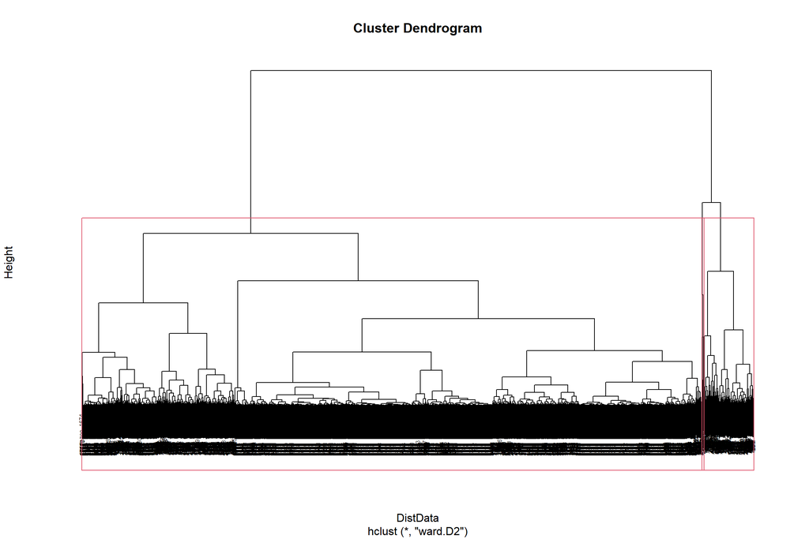

```r
Matrix<- dist(clustering)
hc<-hclust(DistData, method = "ward.D2")
plot(hc, cex=0.5, axes=FALSE)

# silueta
rect.hclust(hc,k=3)
```

```r
groups<-cutree(hc,k=3)
datos$gruposHC<-groups
silhc<-silhouette(groups,DistData)
mean(silhc[,3])
```

```
## [1] 0.6706415
```

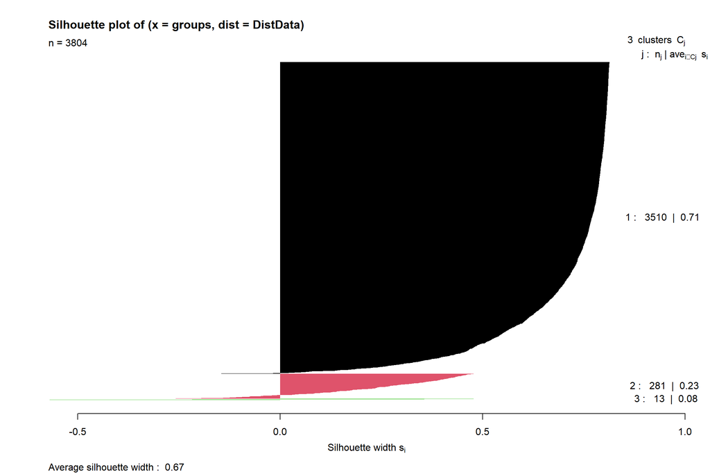

```r
Jerarquico<-mean(silhc[,3])
plot(silhc, cex.names=.4, col=1:3, border = NA)
```

Se puede ver en la grafica con la silueta que los clusters utilizados se alinean en la mayoria solo unos pocos son atipicos

#### Medias

```r
mean(x = norm$popularity, na.rm = TRUE)
```

```
## [1] 68.1854
```

Media de popularidad, 68.1854

```r
mean(x = norm$budget, na.rm = TRUE)
```

```
## [1] 24335422
```

Media de budget, 24335422

```r
mean(x = norm$revenue, na.rm = TRUE)
```

```
## [1] 78593938
```

Media de revenue, 78593938

```r
mean(x = norm$runtime, na.rm = TRUE)
```

```
## [1] 103.2592
```

Media de runtime, 103.2592

```r
round(mean(x = norm$voteCount, na.rm = TRUE))
```

```
## [1] 1871
```

Media de voteCount, 1871

#### Moda

```r
tabla <- table(norm$popularity)
head(sort(tabla, decreasing = TRUE), n = 15)
```

```
##
## 15.804 39.372   8.54  9.336   9.34  9.363  9.608   9.83 10.171 10.192 10.243
##      3      3      2      2      2      2      2      2      2      2      2
## 10.303 10.393 10.472 10.767
##      2      2      2      2
```

Moda de popularity es 15.804 y 39.372 con 3 repeticiones

```r
tabla <- table(norm$budget)
head(sort(tabla, decreasing = TRUE), n = 15)
```

```
##
##         0  20000000  10000000  30000000  15000000  40000000  25000000  50000000
##      1688        84        81        77        70        68        57        56
##   5000000  35000000  60000000  12000000 100000000 150000000   4000000
##        52        45        45        42        34        33        32
```

valor 0 son nulls, Moda de budget es 20000000 con 84 repeticiones

```r
tabla <- table(norm$revenue)
head(sort(tabla, decreasing = TRUE), n = 15)
```

```
##
##        0    7e+06     5000    2e+06  3600000  4100000  1.4e+07  1.9e+07
##     1558        3        2        2        2        2        2        2
## 21200000  2.6e+07  2.7e+07    3e+07 34100000  4.3e+07 43300000
##        2        2        2        2        2        2        2
```

valor 0 son nulls, Moda de revenue es 7e+06 con 3 repeticiones

```r
tabla <- table(norm$runtime)
head(sort(tabla, decreasing = TRUE), n = 15)
```

```
##
##  90 100  97  93 102 110  92  95  94 107  96 108  98 109 104
## 143 115  98  93  90  88  86  86  84  84  83  83  82  82  80
```

Moda de runtime son 90 con 143 repeticiones

```r
tabla <- table(norm$voteCount)
head(sort(tabla, decreasing = TRUE), n = 15)
```

```
##
##   4  18 179   6  13  52  65   3  34  46  57  90 215   1   2
##  15  13  12  11  11  11  11  10  10  10  10  10  10   9   9
```

moda de voteCount es 4 con 15 repeticiones

#### Mediana

```r
with(norm, median(popularity))
```

```
## [1] 24.9505
```

Mediana de popularity, 24.9505

```r
with(norm, median(budget))
```

```
## [1] 3500000
```

Mediana de budget 3500000

```r
with(norm, median(revenue))
```

```
## [1] 3982341
```

Mediana de revenue 3982341

```r
with(norm, median(runtime))
```

```
## [1] 102
```

Mediana de runtime 102

```r
with(norm, median(voteCount))
```

```
## [1] 680.5
```

Mediana de voteCount 680.5

### Trabajo que sigue: Describe el trabajo que desarrollará a partir de la generación de grupos, las tendencias que investigará partiendo de lo que descubrió.

Con los datos obtenidos lo que podemos hacer para los proximos pasos es usar estos grupos para ver cuales son los usarios que ven las peliculas y mejorar el presupuesto de las peliculas. Tambien se pueden ver que es lo que tienen en comun las peliculas mas populares y asi tener un mejor exito ya que al tener mas datos se pueden crear las peliculas y ya se va a saber si lo que se entrega sera una pelicula popular.